# How many, when and which birds to equip?

Using ringing data to inform the deployment of geolocators

### Affiliations

Raphaël Nussbaumer

A Rocha Kenya, Watamu, Kenya,Swiss Ornithological Institue, Sempach, Switzerland

Kirao Lennox

A Rocha Kenya, Watamu, Kenya

Felix Liechti

Swiss Ornithological Institue, Sempach, Switzerland

Colin Jackson

A Rocha Kenya, Watamu, Kenya

### Published

Dec. 20, 2020

# Abstract

Light-level geolocators are increasingly used to study the migration of small birds. Thanks to their relatively low cost, they are particularly well-positioned to be deployed broadly across less well-financed and understudied regions of the world, such as the Africa. A main drawback of geolocators is the need to recapture equipped birds to retrieve the data. Therefore, maximizing the recapture rate is critical to the success of any geolocator study. Using the example of a geolocator study on the coast of Kenya on Red-capped Robin-chats, this paper demonstrates how the use of an ringing data can help optimize the deployment of geolocators, both in terms of how many birds to set out to equip, and when/which birds to equip to maximize recapture in the subsequent years. We found that ringing data can help accurately estimate how many geolocators to order and provides insights into which classes of birds (based on age, capture history, and timing within the season) are most likely to be recaptured.

# Introduction

Light-level geolocators are a well-established technology used to study bird migration. They have become popular due to their relatively low cost and light weight, making them the only tool available to study migration patterns of smaller birds (Bridge et al. 2011). For these reasons, geolocators have helped advance our understanding of bird migration on a number of levels: identifying migration routes and wintering locations (e.g. Salewski et al. 2013; Smith et al. 2014; Liechti et al. 2015; Kralj et al. 2020), revealing migration strategies (e.g. Adamík et al. 2016; Briedis et al. 2019; Hahn et al. 2020) and migratory connectivity (e.g. Finch et al. 2015; Procházka et al. 2017; McKinnon and Love 2018), among others. Geolocators bear strong potential to uncover long-distance Afro-tropical migration patterns, many of which remain still largely unknown (e.g. Benson 1982; Bennun 2000; Cox et al. 2011; Bussière, Underhill, and Altwegg 2015; Nwaogu and Cresswell 2016; Osinubi 2018). As habitat destruction and climate change accelerate and adversely affect migrant birds, it is becoming urgent to better understand these patterns to effectively protect these migratory bird populations (e.g. Simmons et al. 2004; Sekercioglu 2010; Şekercioĝlu, Primack, and Wormworth 2012; Vickery et al. 2014). Geolocators are instrumental in helping us gain understanding of migration routes, timing, triggers and variability, as well as identifying breeding, wintering and stopover sites to protect. Thanks to their low price, geolocators are particularly well-suited to projects with limited budgets. However, geolocators are not without drawbacks. The tags must be retrieved to recover data, harnesses can fail, bird survival might be impacted, latitudinal precision can be relatively poor, and the data analysis can be difficult and prone to errors. With the increasing number of studies using geolocators, these challenges have been partially addressed. Increased experience with this technology has helped improve survival rates through minimum relative load and non-elastic harness technology (e.g. Streby et al. 2015; Weiser et al. 2015; Brlík et al. 2020). Data analysis has also become more accessible and accurate (e.g. Lisovski et al. (2012); Lisovski et al. (2020)) and common pitfalls in analysis have been discussed (e.g. Fudickar, Wikelski, and Partecke 2012; Lisovski et al. 2012, 2018). Finally, more recent geolocators also measure temperature, air pressure and bird activity, providing further precision in geolocation and additional research opportunities (e.g. Meier et al. 2018; Liechti et al. 2018; Dhanjal-Adams et al. 2018; Sjöberg et al. 2018; Jiguet et al. 2019; Briedis et al. 2020). Despite this progress, geolocator studies still need to be carefully planned (in terms of field time, research questions, sample size etc.) to improve the recapture rate of birds in subsequent years. In this study, we present an example of one geolocator study carried out on two Afro-tropical migrants in Kenya. This study will demonstrate how pre-deployment analysis using an existing ringing database can help optimize the deployment of geolocators. We focus on two questions in particular: (1) how many birds can we expect to capture during a full season for a given ringing schedule and (2) how can we maximize bird recapture by equipping specific classes of birds (e.g. sex, age) during specific periods of the year?

# Materials and methods

## Ringing site and database

The A Rocha Kenya Conservation Centre is located on the coast of Kenya and in the middle of the Northern Zanzibar-Inhambane Coastal Forest Mosaic ecoregion ([3°22’36.3“S 39°59’16.9”E](https://goo.gl/maps/4Lrz8iBHdvjnZCNg9)). This region is recognized for its high biodiversity value (Marris 2010) yet faces increasing habitat fragmentation due to the expansion of agriculture and charcoal burning (Burgess and Clarke 2000).

The Conservation Centre is located on a residential coastal scrub/forest that has benefited from limited habitat change over the last 50 years (Alemayehu 2016), in the effort to preserve the ecosystems for tourism purposes. Mist nets are placed in a nature trail that runs through a small patch of forest managed by the Conservation centre.

In addition, we also present the ringing data of 2020, when the geolocators were first deployed. We did not include this data in the fitting of the models but rather used it for comparison and discussion purposes.

In this case study, geolocators were placed on Red-capped Robin-chats Cossypha natalensis (RCRC), a terrestrial thrush wintering in the area from April to October, to uncover their summering site and migration routes (Nussbaumer and Jackson 2020). RCRC are known to hold territory on their wintering sites and show site fidelity (C. Jackson, personal communication), thus making them an ideal candidate for a geolocator study.

## Capture model

In the first step, we modelled the number of RCRC captured per session using a generalized additive model (GAM), assuming the number of captures follows a Poisson distribution. The predictor variables tested in the model are (1) year (2) day-of-year, (3) duration of the session, (4) total length of nets, (5) starting time and (6) weather conditions. To overcome the lack of sufficient data for the duration, start time and length of nets, we used multiple imputation methods by chained equations (Azur et al. 2011) to generate 30 sets of data without any missing values. For each of these sets, a GAM model was fitted.

In the second step, we addressed the problem that RCRC can only be equipped once a year. A first approach tested was to model the count of new birds (i.e., birds that have not yet been captured in the same year) rather than the total number of birds. However, this count depends on how many RCRC have already been equipped earlier in the year. Instead, we preferred to model the probability that a bird captured was not already captured in the same year. This probability is modelled with a Generalized Linear Model (GLM) using a binomial family and a single explanatory variable consisting of the total number of RCRC captured in the year.

## Recapture model

Data collected by geolocators can only be retrieved if the equipped bird is recaptured in the following years. Consequently, to optimize the study it is essential to equip those birds that are most likely to be recaptured. Here too, the ringing database can inform this decision, in this case by providing the recapture rate of a bird as a function of the date of equipping but also of the age and weight of the bird. Using this information, the ringer can make an informed decision about whether or not to equip a captured bird. This decision should also account for the total number of geolocators available and the number of sessions left.

In this study we looked at two parameters: the time of year and the age class (adult or juvenile). The recapture probability is estimated by modelling the binomial response of whether a captured bird will be recaptured in the following years: we consider that an individual is recaptured if the bird has been recaptured at least once in any of the following years, and this is independent from whether it was already captured in the past. We modelled the count of adults and juveniles per session separately to reveal the influence of age on recapture rates. The weight of the bird was left out of the model as it showed little to no effect on the recapture rate (see Figure 12 in SM3. Recapture model). Additionally, we also compare the recapture rate for RCRC captured for the first time and those which have already been equipped.

All computation was performed on R (R Core Team 2013), using the MCGV package (Wood 2017) for GAM, and the Mice Package (Buuren and Groothuis-Oudshoorn 2011) for the imputation.

# Results

## Capture model

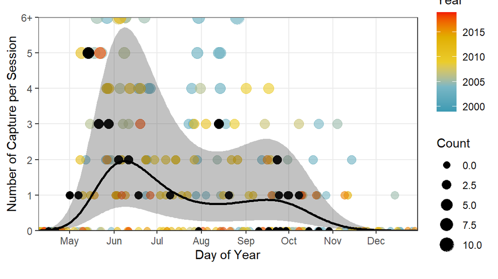

Figure 1: Seasonal variation in the number of captured RCRC per session. Points represent actual data points while the black line is the model estimate for the default/average case (156m, 4hr) with its corresponding uncertainty illustrated as shaded area. Sessions with 6 or more RCRC are illustrated on the “6+” line but with proportionate size and colour. Black points correspond to the 2020 data, when the geolocators were equipped.

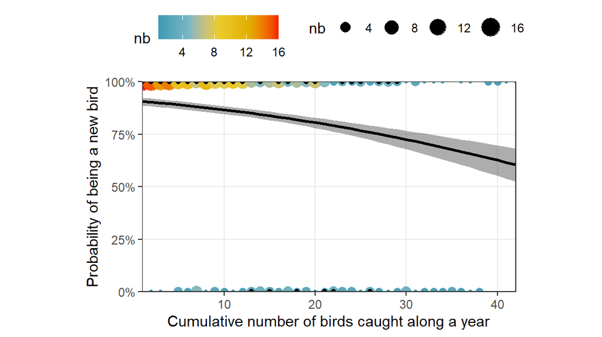

Figure 2: The probability of capturing a new bird (i.e., a bird not yet captured in the current year) as a function of the number of RCRC capture increases. The colour and size of the points indicate the number of occurrences in the dataset that the nth bird caught in a year had already been caught during the year (bottom, old bird, 0%) or the first time it was caught this year (top, new bird, 100%). The line shows the fitted model of the probability that a bird is a new bird as a function of its rank of capture.

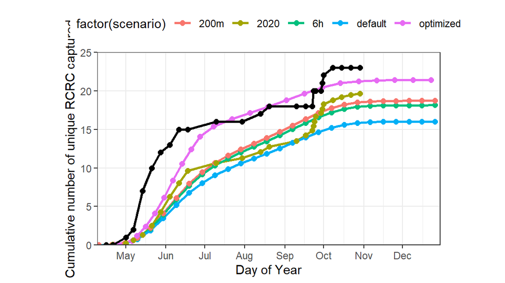

In 2020, 27 ringing sessions were held with 156 m of mist nets, with an average duration of 3:45 (SD: 0:59). As of the 1st of November, a total of 29 RCRC were capture from 23 unique individuals. For the exact same information, the model predicted an expected total of 23 RCRC from 20 individuals.

## Recapture model

Over the 161 unique RCRC individuals captured in the dataset, 67 (42%) were recaptured at least once (including recapture the same year). When considering the 301 capture events (including same individuals), the general recapture rate increases to 47%. However, looking at captures with recapture in any subsequent year, the recapture rate is 30%. In the rest of the study, we employ the latter definition of recapture rate to eliminate intra-season recaptures and consider only recaptures in subsequent years, when geolocators can be retrieved.

In general, adults show a slightly higher recapture rate (34%) than juveniles (27%). When modelled over the day of year (Figure 4a), the recapture rate in subsequent years shows that birds equipped later in the year are twice as likely to be recaptured, with a recapture rate increasing from 25% to almost 50%. Separating adults from juveniles allows us to identify further trends. The increase in juveniles’ recapture rate is not significant. By contrast, adults show a clear increase from May to August, before stabilising from September to October. Modelling the number of captures of adults and juveniles (Figure 4b), we observe an earlier arrival of juveniles (late May vs early June for adults) and earlier departure in August, while adults show a second peak early October.

Finally, a RCRC which has already been captured in the past has a higher recapture rate (36%) compared to a bird without a ring (24).

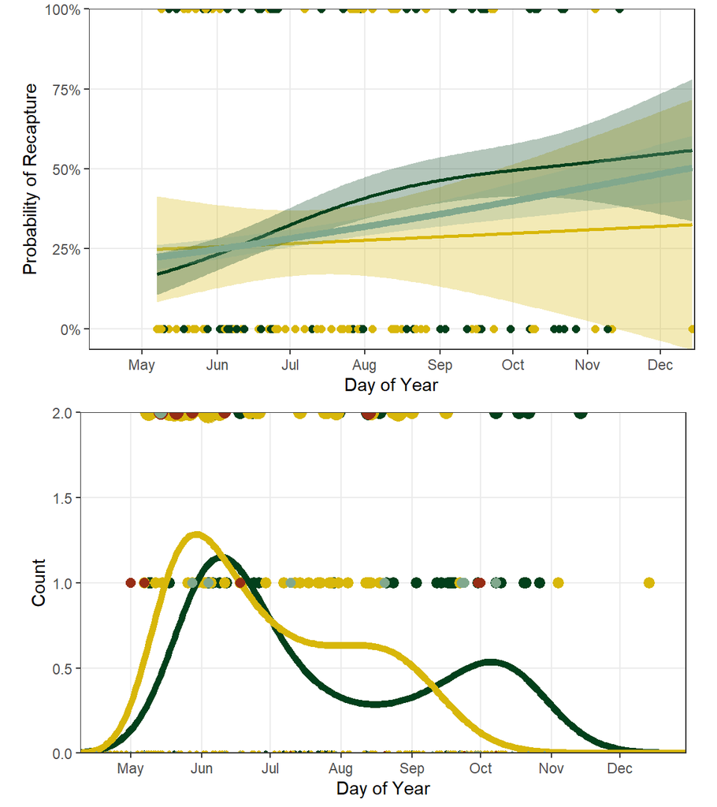

Figure 4: Comparison of adult (green) and juvenile (yellow) trend in (a) recapture rate in subsequent year and (b) number of captures per session throughout the year.

# Discussion

In this paper, we provide an example of how a ringing dataset can inform the design and planning of a geolocator study.

## How many captures?

The method outlined above allows us to estimate the total number of individual birds that can be captured and equipped with geolocators during a single season while accounting for the ringing schedule (number of sessions along the year, length of nets, and session duration).

In 2020, the initial plan was to ring at minimum every two weeks, and every week during peak passage (from May to early June and from late August to October). Following an earlier and simpler capture model (not accounting for annual trends or recapture rates), we expected to capture a total of 30 individuals. Because of uncertainties surrounding the first deployment year, we conservatively requested 15 geolocators. This was meant to allow for flexibility in learning how to equip, and how to select which birds to equip and when throughout the year.

## How to improve recapture rates?

For the geolocator study to be successful, not only do we need to maximize the number of birds equipped (with minimal ringing effort), but also optimize their recapture (i.e. number of geolocators retrieved). We analysed the recapture data for two parameters: age class, and capture date in the year.

We can loosely validate the capture model results with the actual data collected in 2020, though caution is needed as this represents only a single year. The number of RCRC captured in 2020 is comparable to the model estimate, albeit slightly higher. The arrival date proved to be earlier than the average and the numbers appeared to be higher than average at the beginning of the season. This could be due to a particularly good breeding season (many juveniles caught during this period) and/or affected by the playback used near the nets (not done in previous years).  
The approach followed in this paper contains some limitations. Firstly, we considered a recapture as when a bird was captured again in any subsequent year of the initial capture. However, for a geolocator study, the recapture needs to happen within the duration of the study. The recapture rate of the full dataset (30%) reduces to 19% when considering only recaptures happening exactly the following year, 26% for the following 2 years, and 28% for the following 3 years. This suggests that we should keep ringing for at least 2 seasons after captures to benefit from a maximum of geolocator data. Secondly, by using recapture data from the ringing database as a proxy for recaptures involving geolocators, we ignore the effect of geolocators on survival rate (or site fidelity). There have been instances where geolocators have had an impact on survival, thus leading to lower recapture rates than for rings (unknown effect of ring).

Although the model and results of this study are tailored for the specific case of RCRC on coastal Kenya, the application of this methodology can be extended to other situations where ringing data are available for a study site. In general, our methodology is only applicable for cases where the deployment of geolocators is performed with the same technique (e.g. mist net, nest trap, spring nest trap) and context (e.g. place, time, general ringing effort) as the ringing database. In this study, we carried out analyses comparing only adults and juveniles, because it is not possible to determine the sex of a bird in hand. The same analysis can be performed on any class of bird identified by ringers (sex, molt stage, breeding status, subspecies).

# Conclusion

The use of geolocators to study the migratory patterns of smaller birds has accelerated in recent years, offering an affordable solution to better understand, or uncover yet unknown migration routes and sites. This is of particular relevance for Afro-tropical migrants, many of which are still widely understudied and poorly understood, often due to lack of adequate research funding. Along with an increased collective experience in geolocator deployment, the design of studies and analysis of retrieved data has considerably improved. To further contribute to this effort, this study explores avenues for optimizing the deployment of geolocators, in terms of how many, when, and which birds to equip throughout a ringing season in order to maximize re-capture and subsequent retrieval of data. Using the case study of a geolocator study on Red-capped Robin-chats, we exploit the potential of an existing ringing database to inform these questions and design a study. This initial research opens the door for further applications of ringing data to inform geolocator studies.

# Supplementary Materials

## SM1. Data extends

The ringing sessions are relatively well-spread throughout the year (y-axis in Figure 5), although with a slightly higher intensity in March-April than June-July or December-January. The distribution is more heterogenous when comparing different years (x-axis in Figure 5): there is very good coverage between 2003 and 2007, variable from 2008 to 2012, and relatively correct since then.

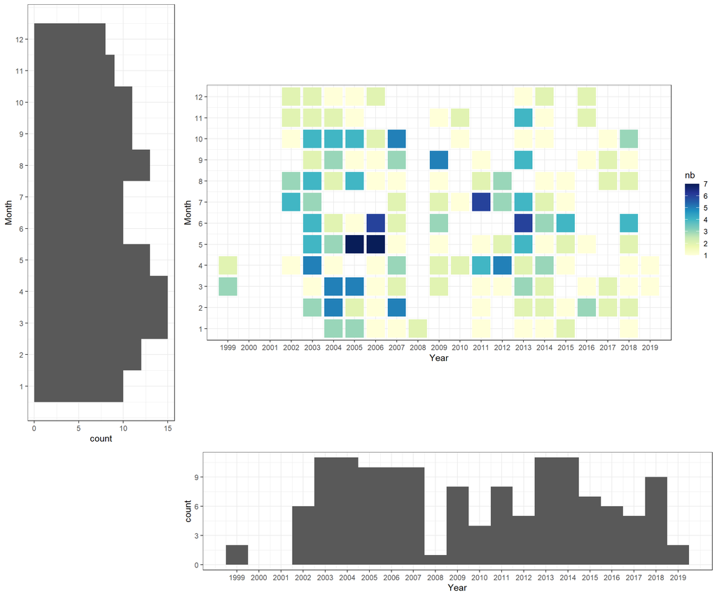

Figure 5: Distribution of the ringing sessions according to year and month. Colour scale indicates the number of ringing sessions.

Additional information for each session was available for some sessions: start time (data available for 74% of the sessions), closing time (39%), sum of net lengths (23%), weather conditions (45%).

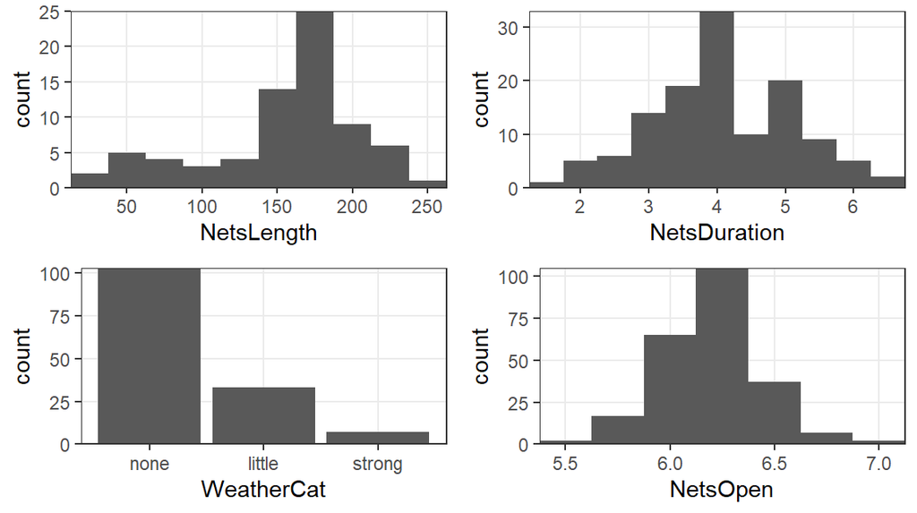

Figure 6: Histograms of the metadata collected for each ringing session (N=317) of (a) total length of nets (N=73), (b) duration of ringing session (N=124), (c) weather category (N=143) and (d) time of session start (N=235).

|  | SessionID | Date | DayOfYear | Year | fYear | Count | CountAd | CountJuv | NetsLength | NetsOpen | NetsDuration | WeatherCat |
| --- | --- | --- | --- | --- | --- | --- | --- | --- | --- | --- | --- | --- |
| 1 | 31 | 1999-03-05 | 64 | 1999 | 1999 | 0 | 0 | 0 | 99 | 5.91666666666667 | 5.08333333333333 | none |
| 2 | 34 | 1999-03-18 | 77 | 1999 | 1999 | 0 | 0 | 0 |  |  |  |  |
| 3 | 35 | 1999-03-19 | 78 | 1999 | 1999 | 0 | 0 | 0 |  |  |  |  |
| 4 | 36 | 1999-04-01 | 91 | 1999 | 1999 | 0 | 0 | 0 |  |  |  |  |
| 5 | 42 | 1999-04-19 | 109 | 1999 | 1999 | 0 | 0 | 0 | 48 | 6.5 | 4 |  |
| 6 | 107 | 2002-04-20 | 110 | 2002 | 2002 | 0 | 0 | 0 | 75 |  |  |  |
| 7 | 108 | 2002-07-27 | 208 | 2002 | 2002 | 3 | 0 | 2 |  | 6.33333333333333 |  |  |
| 8 | 109 | 2002-07-29 | 210 | 2002 | 2002 | 1 | 0 | 1 |  | 6.33333333333333 |  |  |
| 9 | 172 | 2002-07-30 | 211 | 2002 | 2002 | 5 | 1 | 2 | 180 | 6.25 |  |  |
| 10 | 173 | 2002-07-31 | 212 | 2002 | 2002 | 7 | 2 | 3 | 119 | 6.16666666666667 |  |  |

[output cut: 307 more lines]

Figure 7: Sessions dataset

|  | RingNo | Date | Year | DayOfYear | retrap_i | isRetrap | isARetrap | nextSeason | duration_next_capture | duration_last_capture | isAdult | Yearsince | Weight |
| --- | --- | --- | --- | --- | --- | --- | --- | --- | --- | --- | --- | --- | --- |
| 1 | AA0043 | 2002-07-27 | 2002 | 208 | 0 | 1 | False | False | 3 | 3 | False | 0 | 33.7000007629395 |
| 2 | AA0046 | 2002-07-27 | 2002 | 208 | 0 | 1 | False | True | 31 | 739 | False | 0 | 29 |
| 3 | AA0047 | 2002-07-27 | 2002 | 208 | 0 | 0 | False | False |  | 0 | False | 0 | 30.6000003814697 |
| 4 | AA0062 | 2002-07-29 | 2002 | 210 | 0 | 1 | False | True | 1412 | 1412 | False | 0 |  |
| 5 | AA0043 | 2002-07-30 | 2002 | 211 | 1 | 0 | False | False |  | 0 | False | 0 | 32.0999984741211 |
| 6 | AA0067 | 2002-07-30 | 2002 | 211 | 0 | 1 | False | True | 1 | 2591 | True | 0 | 57.2999992370605 |
| 7 | AA0068 | 2002-07-30 | 2002 | 211 | 0 | 1 | False | True | 1 | 302 | False | 0 | 30.6000003814697 |
| 8 | AA0069 | 2002-07-30 | 2002 | 211 | 0 | 1 | False | True | 303 | 332 | False | 0 | 30.5 |
| 9 | AA0074 | 2002-07-30 | 2002 | 211 | 0 | 0 | False | False |  | 0 | False | 0 | 30.3999996185303 |
| 10 | AA0067 | 2002-07-31 | 2002 | 212 | 1 | 1 | False | True | 300 | 2590 | True | 0 | 36 |

[output cut: 291 more lines]

Figure 8: Rings dataset

|  | date | Date | DayOfYear | Count | CountFOY | CountJuv | CountAd | OpenTime | CloseTime | Duration | CountFOY.cum |
| --- | --- | --- | --- | --- | --- | --- | --- | --- | --- | --- | --- |
| 1 | 2020-04-16 | 2020-04-16 | 107 | 0 | 0 | 0 | 0 | 6.25 | 10.25 | 4 | 0 |
| 2 | 2020-04-21 | 2020-04-21 | 112 | 0 | 0 | 0 | 0 | 6.16666666666667 | 9 | 2.83333333333333 | 0 |
| 3 | 2020-05-01 | 2020-05-01 | 122 | 1 | 1 | 1 | 0 | 6.33333333333333 | 10 | 3.66666666666667 | 1 |
| 4 | 2020-05-07 | 2020-05-07 | 128 | 1 | 1 | 1 | 0 | 6.16666666666667 | 9.5 | 3.33333333333333 | 2 |
| 5 | 2020-05-14 | 2020-05-14 | 135 | 5 | 5 | 3 | 2 | 6.16666666666667 | 9.5 | 3.33333333333333 | 7 |
| 6 | 2020-05-21 | 2020-05-21 | 142 | 3 | 3 | 3 | 0 | 6.25 | 10.5 | 4.25 | 10 |
| 7 | 2020-05-28 | 2020-05-28 | 149 | 3 | 2 | 2 | 1 | 6.25 | 11.5 | 5.25 | 12 |
| 8 | 2020-06-04 | 2020-06-04 | 156 | 2 | 1 | 1 | 1 | 6.25 | 11.5 | 5.25 | 13 |
| 9 | 2020-06-11 | 2020-06-11 | 163 | 2 | 2 | 2 | 0 | 6.08333333333333 | 10.25 | 4.16666666666667 | 15 |
| 10 | 2020-06-18 | 2020-06-18 | 170 | 1 | 0 | 1 | 0 | 6 | 10 | 4 | 15 |

[output cut: 17 more lines]

Figure 9: 2020 dataset

## SM2. Capture model

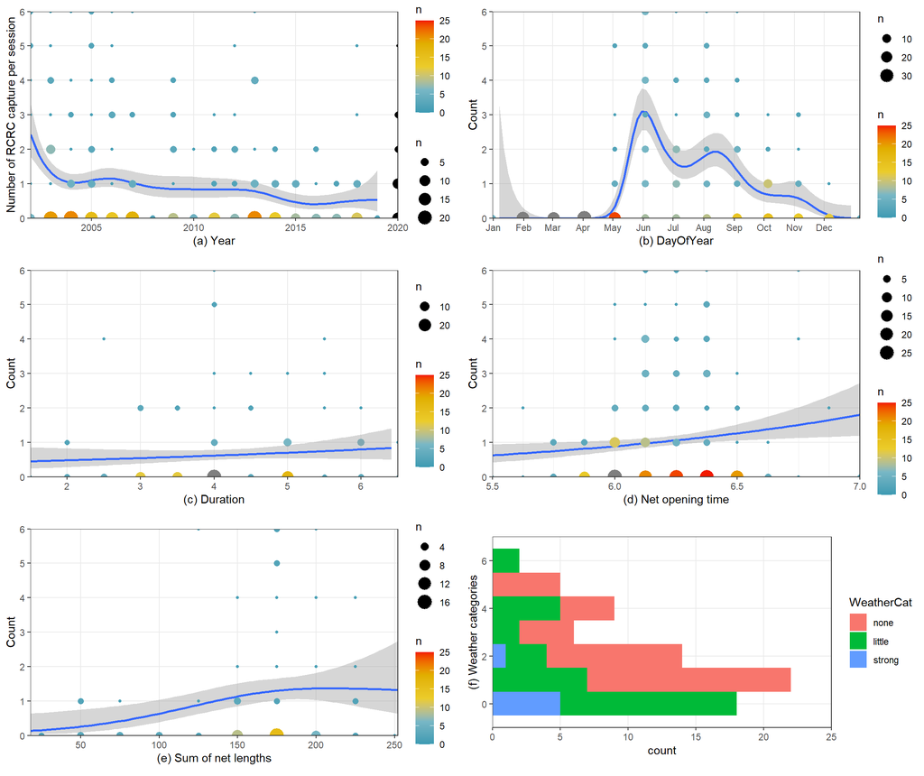

The retained model was `Count ~ s(Year) + s(DayOfYear) + NetsDuration + NetsLength`.

```
Family: poisson
Link function: log

Formula:
Count ~ s(Year) + s(DayOfYear) + NetsDuration + NetsLength

Parametric coefficients:
               Estimate Std. Error z value Pr(>|z|)
(Intercept)  -5.0138065  0.7088758  -7.073 1.52e-12 ***
NetsDuration  0.1368145  0.0383356   3.569 0.000359 ***
NetsLength    0.0047463  0.0008954   5.301 1.15e-07 ***
---
Signif. codes:  0 '***' 0.001 '**' 0.01 '*' 0.05 '.' 0.1 ' ' 1

Approximate significance of smooth terms:
               edf Ref.df Chi.sq p-value
s(Year)      7.957  8.608  122.8  <2e-16 ***
s(DayOfYear) 8.892  8.991  169.3  <2e-16 ***
---
Signif. codes:  0 '***' 0.001 '**' 0.01 '*' 0.05 '.' 0.1 ' ' 1

R-sq.(adj) =   0.46   Deviance explained = 56.4%
UBRE = 0.10585  Scale est. = 1         n = 634
```

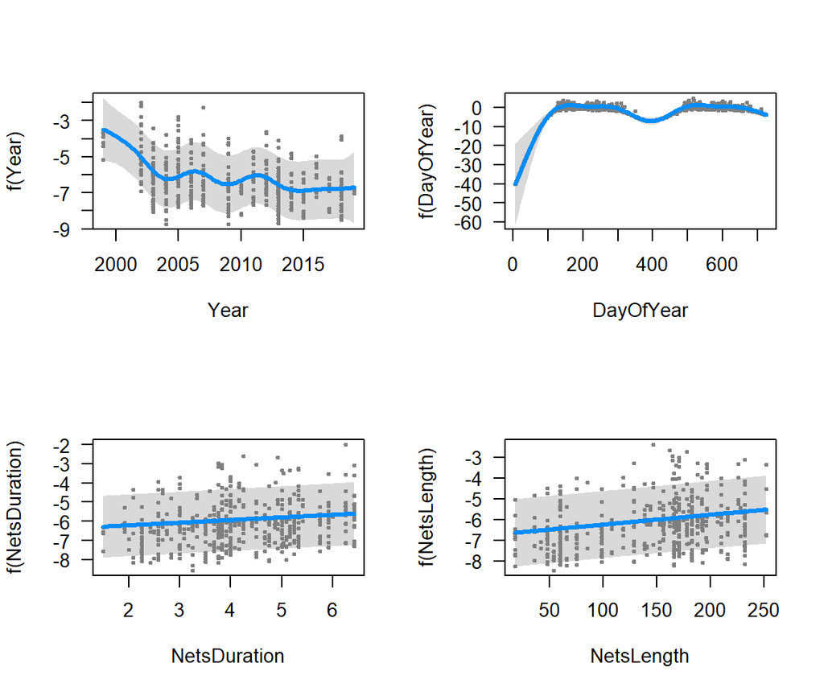

Figure 11: Visual summury of the count model fit (GAM)

## SM3. Recapture model

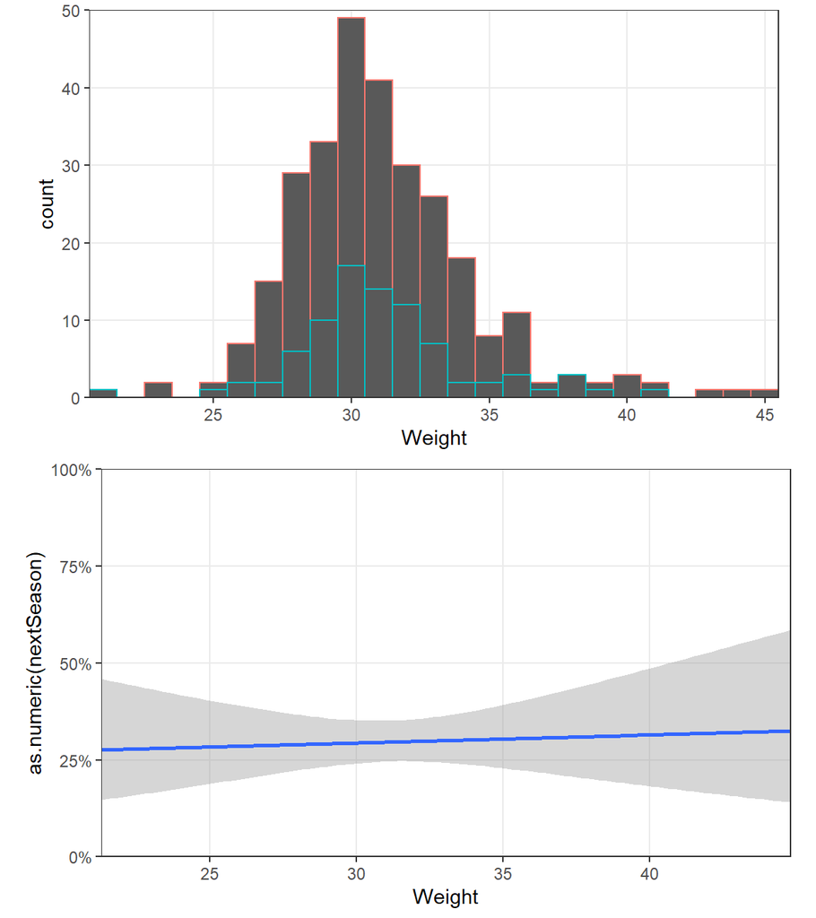

Figure 12: Histograms of the weight of RCRC recaptured in a following year and those not recaptured, together with the model fit. The uncertainty of the model shows that weight has an unclear influence on the recatpure rate.

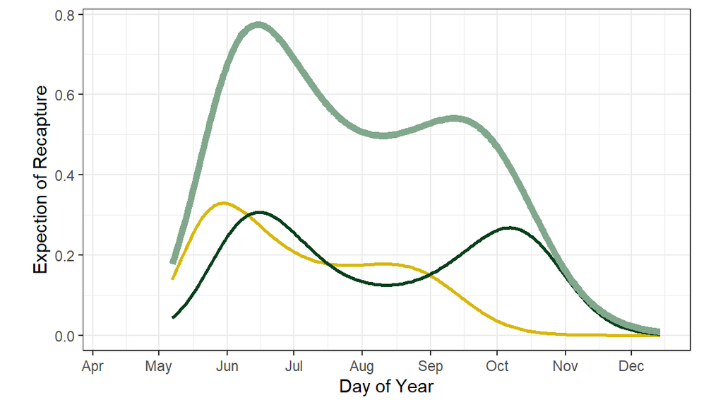

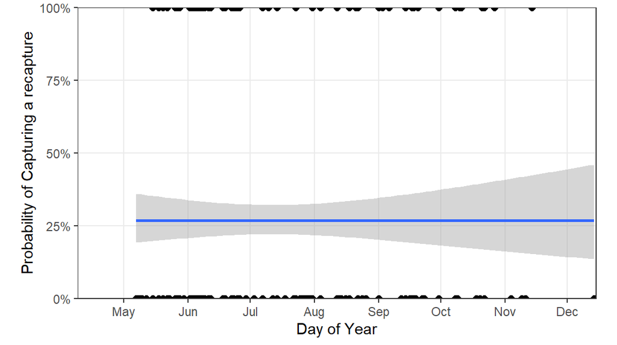

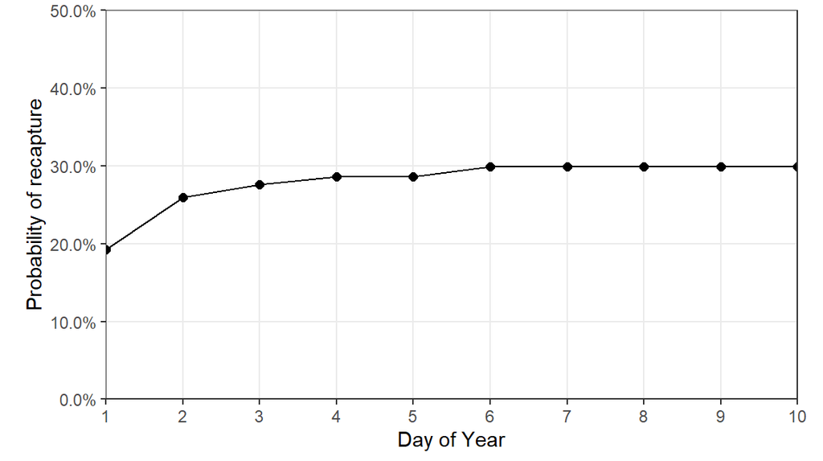

```
Call:
glm(formula = isFirstOfYear ~ CountOfYear, family = "binomial",
    data = dmf)

Deviance Residuals:
    Min       1Q   Median       3Q      Max
-2.2001   0.4315   0.4603   0.5688   1.0015

Coefficients:
            Estimate Std. Error z value Pr(>|z|)
(Intercept)  2.32700    0.07587   30.67   <2e-16 ***
CountOfYear -0.04519    0.00372  -12.15   <2e-16 ***
---
Signif. codes:  0 '***' 0.001 '**' 0.01 '*' 0.05 '.' 0.1 ' ' 1

(Dispersion parameter for binomial family taken to be 1)

    Null deviance: 2858.4  on 3371  degrees of freedom
Residual deviance: 2713.4  on 3370  degrees of freedom
AIC: 2717.4

Number of Fisher Scoring iterations: 4
```

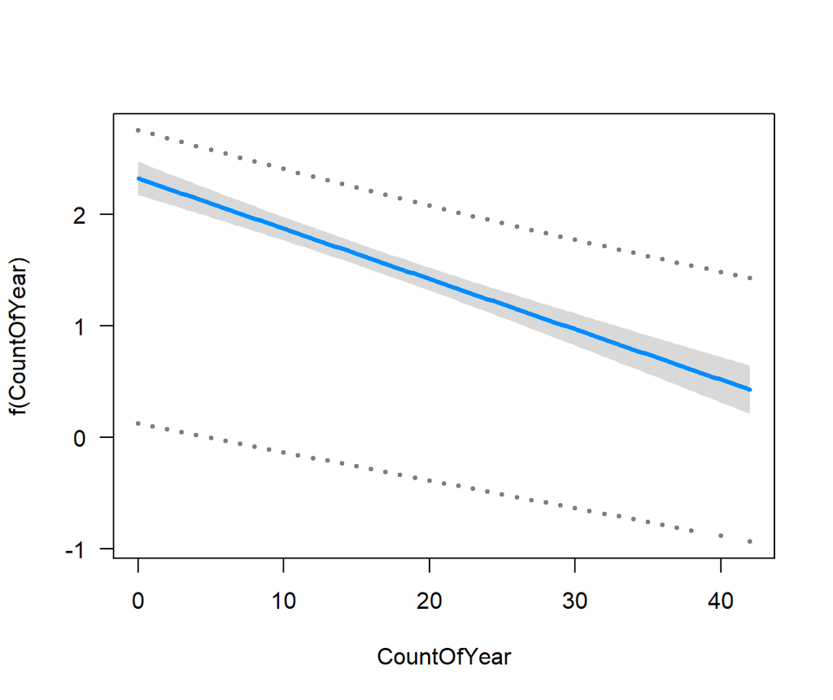

Figure 13: Visual summury of the recapture model fit (GLM)

### Acknowledgements

This work was supported by a grant from the Swiss Ornithological Institute. We thank A Rocha Kenya for providing their ringing dataset, and for carrying out field work to equip Red-capped Robin-chats with geolocators. We thank Martins Briedis, Matthew Sjaarda, Burri Reto and Améline Nussbaumer for their valuable contributions to the paper.

### Data Accessibility

https://github.com/A-Rocha-Kenya/How-many-when-and-which-birds-to-equip

### References

Adamík, Peter, Tamara Emmenegger, Martins Briedis, Lars Gustafsson, Ian Henshaw, Miloš Krist, Toni Laaksonen, et al. 2016. “Barrier crossing in small avian migrants: Individual tracking reveals prolonged nocturnal flights into the day as a common migratory strategy.” *Scientific Reports* 6 (February): 1–9. https://doi.org/10.1038/srep21560.

Alemayehu, Fikir. 2016. “Land Use and Land Cover Change in the Coastal Area of Watamu Mida Creek, Kenya.” *Open Journal of Forestry* 06 (04): 230–42. https://doi.org/10.4236/ojf.2016.64019.

Azur, Melissa J., Elizabeth A. Stuart, Constantine Frangakis, and Philip J. Leaf. 2011. “Multiple imputation by chained equations: what is it and how does it work?” *International Journal of Methods in Psychiatric Research* 20 (1): 40–49. https://doi.org/10.1002/mpr.329.

Bennun, Leon. 2000. “Assessing and monitoring bird populations in Africa: an overview.” *Ostrich* 71 (1-2): 214–15. https://doi.org/10.1080/00306525.2000.9639915.

Benson, C. W. 1982. “Migrants in the Afrotropical Region South of the Equator.” *Ostrich* 53 (1): 31–49. https://doi.org/10.1080/00306525.1982.9634723.

Bridge, Eli S., Kasper Thorup, Melissa S. Bowlin, Phillip B. Chilson, Robert H. Diehl, René W. Fléron, Phillip Hartl, et al. 2011. “Technology on the Move: Recent and Forthcoming Innovations for Tracking Migratory Birds.” *BioScience* 61 (9): 689–98. https://doi.org/10.1525/bio.2011.61.9.7.

Briedis, Martins, Silke Bauer, Peter Adamík, José A. Alves, Joana S. Costa, Tamara Emmenegger, Lars Gustafsson, et al. 2019. “A full annual perspective on sex-biased migration timing in long-distance migratory birds.” *Proceedings of the Royal Society B: Biological Sciences* 286 (1897). https://doi.org/10.1098/rspb.2018.2821.

Briedis, Martins, Václav Beran, Peter Adamík, and Steffen Hahn. 2020. “Integrating light-level geolocation with activity tracking reveals unexpected nocturnal migration patterns of the tawny pipit.” *Journal of Avian Biology* 51 (9): 1–10. https://doi.org/10.1111/jav.02546.

Brlík, Vojtěch, Jaroslav Koleček, Malcolm Burgess, Steffen Hahn, Diana Humple, Miloš Krist, Janne Ouwehand, et al. 2020. “Weak effects of geolocators on small birds: A meta-analysis controlled for phylogeny and publication bias.” *Journal of Animal Ecology* 89 (1): 207–20. https://doi.org/10.1111/1365-2656.12962.

Burgess, N, and G Clarke. 2000. “Coastal forests of eastern Africa.” In.

Bussière, Elsa M. S., Les G. Underhill, and Res Altwegg. 2015. “Patterns of bird migration phenology in South Africa suggest northern hemisphere climate as the most consistent driver of change.” *Global Change Biology* 21 (6): 2179–90. https://doi.org/10.1111/gcb.12857.

Buuren, Stef van, and Karin Groothuis-Oudshoorn. 2011. “mice : Multivariate Imputation by Chained Equations in R.” *Journal of Statistical Software* 45 (3): 1–67. https://doi.org/10.18637/jss.v045.i03.

Cox, Daniel, Miriam Brandt, Ross Mcgregor, Ulf Ottosson, Mathew Stevens, and Will Cresswell. 2011. “Patterns of seasonal and yearly mass variation in West African tropical savannah birds.” *Ibis* 153 (4): 672–83. https://doi.org/10.1111/j.1474-919X.2011.01150.x.

Dhanjal-Adams, Kiran L., Silke Bauer, Tamara Emmenegger, Steffen Hahn, Simeon Lisovski, and Felix Liechti. 2018. “Spatiotemporal Group Dynamics in a Long-Distance Migratory Bird.” *Current Biology* 28 (17): 2824–2830.e3. https://doi.org/10.1016/j.cub.2018.06.054.

Finch, Tom, Philip Saunders, Jesús Miguel Avilés, Ana Bermejo, Inês Catry, Javier de la Puente, Tamara Emmenegger, et al. 2015. “A pan-European, multipopulation assessment of migratory connectivity in a near-threatened migrant bird.” *Diversity and Distributions* 21 (9): 1051–62. https://doi.org/10.1111/ddi.12345.

Fudickar, Adam M., Martin Wikelski, and Jesko Partecke. 2012. “Tracking migratory songbirds: accuracy of light-level loggers (geolocators) in forest habitats.” *Methods in Ecology and Evolution* 3 (1): 47–52. https://doi.org/10.1111/j.2041-210X.2011.00136.x.

Hahn, Steffen, José A. Alves, Kiril Bedev, Joana S. Costa, Tamara Emmenegger, Martin Schulze, Peter Tamm, Pavel Zehtindjiev, and Kiran L. Dhanjal-Adams. 2020. “Range-wide migration corridors and non-breeding areas of a northward expanding Afro-Palaearctic migrant, the European Bee-eater Merops apiaster.” *Ibis* 162 (2): 345–55. https://doi.org/10.1111/ibi.12752.

Jiguet, Frédéric, Malcolm Burgess, Kasper Thorup, Greg Conway, José Luis Arroyo Matos, Lee Barber, John Black, et al. 2019. “Desert crossing strategies of migrant songbirds vary between and within species.” *Scientific Reports* 9 (1): 1–12. https://doi.org/10.1038/s41598-019-56677-4.

Kralj, Jelena, Miloš Martinović, Luka Jurinović, Péter Szinai, Szandra Süto, and Bálint Preiszner. 2020. “Geolocator study reveals east African migration route of Central European Common Terns.” *Avian Research* 11 (1): 1–11. https://doi.org/10.1186/s40657-020-00191-z.

Liechti, Felix, Silke Bauer, Kiran L. Dhanjal-Adams, Tamara Emmenegger, Pavel Zehtindjiev, and Steffen Hahn. 2018. “Miniaturized multi-sensor loggers provide new insight into year-round flight behaviour of small trans-Sahara avian migrants.” *Movement Ecology* 6 (1): 1–10. https://doi.org/10.1186/s40462-018-0137-1.

Liechti, Felix, Chiara Scandolara, Diego Rubolini, Roberto Ambrosini, Fränzi Korner-Nievergelt, Steffen Hahn, Roberto Lardelli, et al. 2015. “Timing of migration and residence areas during the non-breeding period of barn swallows Hirundo rustica in relation to sex and population.” *Journal of Avian Biology* 46 (3): 254–65. https://doi.org/10.1111/jav.00485.

Lisovski, Simeon, Silke Bauer, Martins Briedis, Sarah C. Davidson, Kiran L. Dhanjal‐Adams, Michael T. Hallworth, Julia Karagicheva, et al. 2020. “Light‐level geolocator analyses: A user’s guide.” Edited by Garrett Street. *Journal of Animal Ecology* 89 (1): 221–36. https://doi.org/10.1111/1365-2656.13036.

Lisovski, Simeon, Chris M. Hewson, Raymond H. G. Klaassen, Fränzi Korner-Nievergelt, Mikkel W. Kristensen, and Steffen Hahn. 2012. “Geolocation by light: Accuracy and precision affected by environmental factors.” *Methods in Ecology and Evolution* 3 (3): 603–12. https://doi.org/10.1111/j.2041-210X.2012.00185.x.

Lisovski, Simeon, Heiko Schmaljohann, Eli S. Bridge, Silke Bauer, Andrew Farnsworth, Sidney A. Gauthreaux, Steffen Hahn, et al. 2018. “Inherent limits of light-level geolocation may lead to over-interpretation.” *Current Biology* 28 (3): R99–R100. https://doi.org/10.1016/j.cub.2017.11.072.

Marris, Emma. 2010. “Conservation: Biodiversity as a bonus prize.” *Nature* 468 (7326): 895. https://doi.org/10.1038/468895a.

McKinnon, Emily A., and Oliver P. Love. 2018. “Ten years tracking the migrations of small landbirds: Lessons learned in the golden age of bio-logging.” *The Auk* 135 (4): 834–56. https://doi.org/10.1642/auk-17-202.1.

Meier, Christoph M., Hakan Karaardıç, Raül Aymí, Strahil G. Peev, Erich Bächler, Roger Weber, Willem Witvliet, and Felix Liechti. 2018. “What makes Alpine swift ascend at twilight? Novel geolocators reveal year-round flight behaviour.” *Behavioral Ecology and Sociobiology* 72 (3): 45. https://doi.org/10.1007/s00265-017-2438-6.

Nussbaumer, Raphaël, and Colin Jackson. 2020. “Using geolocators to unravel intra-African migrant strategies.” March. Watamu: A Rocha Kenya. https://doi.org/10.13140/RG.2.2.34477.10721.

Nwaogu, Chima Josiah, and Will Cresswell. 2016. “Body reserves in intra-African migrants.” *Journal of Ornithology* 157 (1): 125–35. https://doi.org/10.1007/s10336-015-1259-5.

Osinubi, Samuel Temidayo. 2018. “Intra-African Bird Migration Project : ecology and conservation.” FitzPatrick Institude of African Ornithology.

Procházka, Petr, Steffen Hahn, Simon Rolland, Henk van der Jeugd, Tibor Csörgő, Frédéric Jiguet, Tomasz Mokwa, Felix Liechti, Didier Vangeluwe, and Fränzi Korner-Nievergelt. 2017. “Delineating large-scale migratory connectivity of reed warblers using integrated multistate models.” *Diversity and Distributions* 23 (1): 27–40. https://doi.org/10.1111/ddi.12502.

R Core Team. 2013. “R: A language and environment for statistical computing.” Vienna, Austria.

Salewski, Volker, Martin Flade, Anatolii Poluda, Grzegorz Kiljan, Felix Liechti, Simeon Lisovski, and Steffen Hahn. 2013. “An unknown migration route of the ’globally threatened’ Aquatic Warbler revealed by geolocators.” *Journal of Ornithology* 154 (2): 549–52. https://doi.org/10.1007/s10336-012-0912-5.

Sekercioglu, Cagan H. 2010. “IN FOCUS: Partial migration in tropical birds: the frontier of movement ecology.” *Journal of Animal Ecology* 79 (5): 933–36. https://doi.org/10.1111/j.1365-2656.2010.01739.x.

Simmons, Robert E., Phoebe Barnard, W. R. J. Dean, Guy F. Midgley, Wilfried Thuiller, and Greg Hughes. 2004. “Climate change and birds: Perspectives and prospects from southern Africa.” *Ostrich* 75 (4): 295–308. https://doi.org/10.2989/00306520409485458.

Sjöberg, Sissel, Lykke Pedersen, Gintaras Malmiga, Thomas Alerstam, Bengt Hansson, Dennis Hasselquist, Kasper Thorup, Anders P. Tøttrup, Arne Andersson, and Johan Bäckman. 2018. “Barometer logging reveals new dimensions of individual songbird migration.” *Journal of Avian Biology* 49 (9). https://doi.org/10.1111/jav.01821.

Smith, Malcolm, Mark Bolton, David J. Okill, Ron W. Summers, Pete Ellis, Felix Liechti, and Jeremy D. Wilson. 2014. “Geolocator tagging reveals Pacific migration of Red-necked Phalarope Phalaropus lobatus breeding in Scotland.” *Ibis* 156 (4): 870–73. https://doi.org/10.1111/ibi.12196.

Streby, Henry M., Tara L. McAllister, Sean M. Peterson, Gunnar R. Kramer, Justin A. Lehman, and David E. Andersen. 2015. “Minimizing marker mass and handling time when attaching radio-transmitters and geolocators to small songbirds.” *The Condor* 117 (2): 249–55. https://doi.org/10.1650/condor-14-182.1.

Şekercioĝlu, çaĝan H., Richard B. Primack, and Janice Wormworth. 2012. “The effects of climate change on tropical birds.” *Biological Conservation* 148 (1): 1–18. https://doi.org/10.1016/j.biocon.2011.10.019.

Vickery, Juliet A., Steven R. Ewing, Ken W. Smith, Deborah J. Pain, Franz Bairlein, Jana Škorpilová, and Richard D. Gregory. 2014. “The decline of Afro-Palaearctic migrants and an assessment of potential causes.” Edited by Tony Fox. *Ibis* 156 (1): 1–22. https://doi.org/10.1111/ibi.12118.

Weiser, Emily L., Richard B. Lanctot, Stephen C. Brown, José A. Alves, Phil F. Battley, Rebecca Bentzen, Joël Bêty, et al. 2015. “Effects of geolocators on hatching success, return rates, breeding movements, and change in body mass in 16 species of Arctic-breeding shorebirds.” *Movement Ecology* 4 (1). https://doi.org/10.1186/s40462-016-0077-6.

Wood, Simon N. 2017. *Generalized additive models: an introduction with R*. CRC press.